# Entity Resolution

David Cortes

July 23, 2015

# Description

This example is about Entity Resolution - also called record linkage - on the benchmark dataset of Google and Amazon products which can be found [here](http://dbs.uni-leipzig.de/en/research/projects/object_matching/fever/benchmark_datasets_for_entity_resolution). There are two datasets: one contains product information for several products from Amazon (1362 records) and the other contains information for products taken from Google, which were in turn indexed from different sites (3226 records). The goal is to determine which entries refer to the same product, and there is another document indicating which products are actually the same (1300 matches), so the dataset can be easily used to benchmark different methods. This example was inspired by professor Talwalkar’s computing lab on the course CS100.1x at edX.

Entity Resolution has many applications, the most common being augmenting a database with data taken from a different source (e.g. adding public information to a proprietary dataset). It has also been used in other interesting cases, such as determining which clients came from a specific seller when they both record slightly different information about clients (for example, a client might give his phone number to the seller who first brought it into buying or suscribing to a product, and then give his mobile phone when buying/suscribing it).

### 1. Taking a look at the dataset

```r
amazon <- read.csv("Amazon.csv",stringsAsFactors=FALSE)
google <- read.csv("GoogleProducts.csv",stringsAsFactors=FALSE)
matching <- read.csv("Amzon_GoogleProducts_perfectMapping.csv",stringsAsFactors=FALSE)
names(amazon)[2:5]=names(google)[2:5]
library(xtable)
disp1=xtable(amazon[1:4,2:5])
disp2=xtable(google[1:4,2:5])
disp3=xtable(rbind(amazon[amazon[,1]==matching[1,1],2:5],google[google[,1]==matching[1,2],2:5]))
print("Sample Rows from Amazon");print(disp1,floating=FALSE,type="html",include.rownames = FALSE);print("Sample Rows from Google");print(disp2,floating=FALSE,type="html",include.rownames = FALSE);print("Sample matching entry");print(disp3,floating=FALSE,type="html",include.rownames = FALSE)
```

[1] “Sample Rows from Amazon”

| name | description | manufacturer | price |
| --- | --- | --- | --- |
| clickart 950 000 - premier image pack (dvd-rom) |  | broderbund | 0.00 |
| ca international - arcserve lap/desktop oem 30pk | oem arcserve backup v11.1 win 30u for laptops and desktops | computer associates | 0.00 |
| noah’s ark activity center (jewel case ages 3-8) |  | victory multimedia | 0.00 |
| peachtree by sage premium accounting for nonprofits 2007 | peachtree premium accounting for nonprofits 2007 is the affordable easy to use accounting solution that provides you with donor/grantor management. if you’re like most nonprofit organizations you’re c… | sage software | 599.99 |

[1] “Sample Rows from Google”

| name | description | manufacturer | price |
| --- | --- | --- | --- |
| learning quickbooks 2007 | learning quickbooks 2007 | intuit | 38.99 |
| superstart! fun with reading & writing! | fun with reading & writing! is designed to help kids learn to read and write better through exercises puzzle-solving creative writing decoding and more! |  | 8.49 |
| qb pos 6.0 basic software | qb pos 6.0 basic retail mngmt software. for retailers who need basic inventory sales and customer tracking. | intuit | 637.99 |
| math missions: the amazing arcade adventure (grades 3-5) | save spectacle city by disrupting randall underling’s plan to drive all the stores out of business and take over the city. solve real-world math challenges in the uniquely entertaining stores and make… |  | 12.95 |

[1] “Sample matching entry”

| name | description | manufacturer | price |
| --- | --- | --- | --- |
| clickart 950 000 - premier image pack (dvd-rom) |  | broderbund | 0 |
| clickart 950000 - premier image pack (dvd-rom) | massive collection of images & fonts for all your design needs ondvd-rom!product informationinspire your creativity and perfect any creative project with thousands ofworld-class images in virtually ev… |  | 48.95 |

It can be seen, for example, that for this sample matching record, in one case the number is written with a thousands separator but in the other not, and in one case there is a lot more information than in the other.

## 2. The plan

There are different algorithms that have been proposed to deal with problems of entity resolution, and some do better when there are fields with very specific information such as (First Name, Last Name, Phone Number, Address), which is not the case here.

The algorithm illustrated here consists of doing some word processing on the text fields, converting the text fields to bags of words weighted by their TF-IDF, assigning different weights to each field and computing their similarity (using cosine similarity for text fields - an edit-distance based metric for manufacturer - and a simple formula for the price), to come up with a weighted similarity measure. Then, a sample of matching records will be taken from the matching dataset (using the entire set would be the equivalent of cheating, as what the algorithm tries to do is precisely come up with that dataset when it isn’t available; however, a small sample of matching products could be easily identified by a person to feed into the algorithm, and this process would be ‘simulated’ by picking a random sample from this matching list) and it will be evaluated what is the average similarity among those matching entries and among the other entries to come up with a cut-off threshold to label two records as being the same or not.

Different possibilities will be tried and the resulting matching lists will be evaluated by their accuracy over all pairs, precision, recall and F1 score.

## 3. Processing the data

```r
library(tm)
library(Matrix)

#Trying first with separate fields
a.names=amazon$name
g.names=google$name
a.desc=amazon$description
g.desc=google$description
a.man=amazon$manufacturer
g.man=google$manufacturer
a.pr=amazon$price
g.pr=as.numeric(google$price)
a.pr[a.pr==0]=NA

#Trying also with concatenated columns
a.text=do.call(paste,c(amazon[,2:4]))
g.text=do.call(paste,c(google[,2:4]))

#Building the bags of words
to.spm=function(dtm){
  return(sparseMatrix(i=dtm$i, j=dtm$j, x=dtm$v,dims=c(dtm$nrow, dtm$ncol)))
}

bgwds=function(a,g){
  bg=Corpus(VectorSource(c(a,g)))
  bg=tm_map(bg,content_transformer(tolower))
  bg=tm_map(bg,removeWords,stopwords())
  bg=tm_map(bg,stripWhitespace)
  bg=tm_map(bg,removePunctuation)
  #Stemming would not be appropriate in this case

  bg=DocumentTermMatrix(bg, control = list(weighting = function(x) weightTfIdf(x, normalize = FALSE)))
  bg=to.spm(bg)
  return(bg)
}
a.end=length(a.names)
g.start=a.end+1
g.end=a.end+length(g.names)

nms=bgwds(a.names,g.names)
a.names=nms[1:a.end,]
g.names=nms[g.start:g.end,]

desc=bgwds(a.desc,g.desc)
a.desc=desc[1:a.end,]
g.desc=desc[g.start:g.end,]

tx=bgwds(a.text,g.text)
a.text=tx[1:a.end,]
g.text=tx[g.start:g.end,]

man2=bgwds(a.man,g.man)
a.man2=man2[1:a.end,]
g.man2=man2[g.start:g.end,]
```

## 4. Establishing similarity scores for the price

$sim(record1, record2) = max(0, 1 - 2 \times ln(\frac{record1}{record2}))$

```r
price.sim=function(price1,price2){
  if (is.na(price1)|is.na(price2)){
    return(0)
  } else{
    dif=abs(log(price1,price2))
    return(max(0,1-2*dif))
  }
}


pr.sim=matrix(nrow=length(a.pr),ncol=length(g.pr))
for (record1 in 1:length(a.pr)) {
  for (record2 in 1:length(g.pr)){
    pr.sim[record1,record2]=price.sim(a.pr[record1],g.pr[record2])
  }
}
print(paste0("Average price similarity: ",mean(pr.sim)))
```

```
## [1] "Average price similarity: 0.0154419589482755"
```

## 5. Establishing similarity scores for the manufacturers

Unlike the other text fields, “manufacturer” is a field that contains only a short piece of text, and the edit distance might be a more appropriate metric to compare differences in this field. If we assume that edit distances of around 5 could be reasonable, while not discarding those that have distances of up to 15 (e.g. hp vs. hewlett packard), the similarity could be established by the following formula:

$sim(record1,record2) = \begin{cases} e^{(-\frac{editDist(record1,record2)}{5})} & \text {if }editDist(record1,record2) \leq 15\\ 0 & \quad \quad \quad \quad \quad \quad \quad \quad \text otherwise\\ \end{cases}$

Although I’ll also try a TF-IDF’d bag-of-words cosine similarity as with the other fields (will be computed on the next point).

```r
man.sim=matrix(nrow=length(a.pr),ncol=length(g.pr))
for (record1 in 1:length(a.man)) {
  for (record2 in 1:length(g.man)){
    if (is.na(a.man[record1]) | is.na(g.man[record2])){
     man.sim[record1,record2]=0
    } else {
      edit=man.sim[record1,record2]=adist(a.man[record1],g.man[record2])
      if (edit>15){
        man.sim[record1,record2]=0
      } else {
        man.sim[record1,record2]=exp(-edit/5)
      }
    }
  }
}
```

## 6. Computing cosine similarities

This piece of code would compute the required cosine similarities. However, R is not the most efficient program for these kinds of intensive computations, and it would take more than one day to execute in a desktop computer. Thus, I switched to Spark and generated the desired output, which I then imported into R. Spark did the job in around 20 minutes in a single multicore machine.

*Warning: this is a very slow computation and doesn’t scale well when using R.*

```r
library(lsa)
library(Matrix)

#First with the separate fields
name.sim=matrix(nrow=dim(amazon)[1],ncol=dim(google)[1])
desc.sim=matrix(nrow=dim(amazon)[1],ncol=dim(google)[1])
man2.sim=matrix(nrow=dim(amazon)[1],ncol=dim(google)[1])

#Then with the concatenated fields
txt.sim=matrix(nrow=dim(amazon)[1],ncol=dim(google)[1])

for (record1 in 1:a.end) {
  for (record2 in 1:dim(google)[1]) {
    name.sim[record1,record2]=cosine(a.names[record1,],g.names[record2,])
    desc.sim[record1,record2]=cosine(a.desc[record1,],g.desc[record2,])
    man2.sim[record1,record2]=cosine(a.man2[record1,],g.man2[record2,])
    tx.sim[record1,record2]=cosine(a.text[record1,],g.text[record2,])
  }
}
```

From here on, I’ll continue with the numbers that I got from Spark, which would be the equivalent of executing the code above.

```r
#Writing the files
writeMM(a.names,'a.names')
writeMM(g.names,'g.names')
writeMM(a.desc,'a.desc')
writeMM(g.desc,'g.desc')
writeMM(a.man2,'a.man2')
writeMM(g.man2,'g.man2')
writeMM(a.text,'a.text')
writeMM(g.text,'g.text')
#The first two lines of each were then deleted
```

…Then Spark did its magic… (you can check the code [here](https://github.com/david-cortes/portfolio/blob/master/entity_resolution/heavy_computations.ipynb))

```r
#Reading back the output from Spark
#The files were renamed from 'part-0000' to more indicative names

names.sim.list=read.csv("names.sim", header=FALSE, quote="", comment="")
desc.sim.list=read.csv("desc.sim", header=FALSE, quote="", comment="")
man2.sim.list=read.csv("man2.sim", header=FALSE, quote="", comment="")
text.sim.list=read.csv("text.sim", header=FALSE, quote="", comment="")

#The output in this case is in the form of a list of Amazon-Google-Similarity triples, so I'll now turn each into a matrix
name.sim=matrix(nrow=dim(amazon)[1],ncol=dim(google)[1])
desc.sim=matrix(nrow=dim(amazon)[1],ncol=dim(google)[1])
man2.sim=matrix(nrow=dim(amazon)[1],ncol=dim(google)[1])
txt.sim=matrix(nrow=dim(amazon)[1],ncol=dim(google)[1])

#Warning: these loops are very slow and if the data were larger, it would be easier to export these whole matrices from Spark
for (i in 1:dim(names.sim.list)[1]){
  name.sim[names.sim.list[i,1], names.sim.list[i,2]]=names.sim.list[i,3]
}
name.sim[is.na(name.sim)]=0

for (i in 1:dim(desc.sim.list)[1]){
  desc.sim[desc.sim.list[i,1], desc.sim.list[i,2]]=desc.sim.list[i,3]
}
desc.sim[is.na(desc.sim)]=0

for (i in 1:dim(man2.sim)[1]){
  man2.sim[man2.sim[i,1], man2.sim[i,2]]=man2.sim[i,3]
}
man2.sim[is.na(man2.sim)]=0

for (i in 1:dim(names.sim.list)[1]){
  txt.sim[text.sim.list[i,1], g=text.sim.list[i,2]]=text.sim.list[i,3]
}
txt.sim[is.na(txt.sim)]=0
```

## 7. Picking a sample of matching pairs

Now I’ll pick a random sample of 100 records that are known to be the same - this would normally be done by manually picking records until 100 identical ones are identified, but since there is already a list of perfect matches, I’ll skip that part and just use part of that list (see explanation in section 2) to save time, and keep a list of the ones that were not maches too. This would have required a manual examination of about 333,333 records if there were no such list, so it might have been a good idea to just blindly set an arbitrary similarity threshold before starting to pick pairs (this is no problem for a computer simulation though).

Then, I’ll see what is the average similarity of each field in that small subsample, compared to the average similarity of non-matching records.

```r
library(dplyr)

lookup.amazon=data.frame(amazon[,1],1:dim(amazon)[1])
names(lookup.amazon)=c('idAmazon','numA')
lookup.google=data.frame(google[,1],1:dim(google)[1])
names(lookup.google)=c('idGoogleBase','numG')
matching=matching %>% left_join(lookup.amazon) %>% left_join(lookup.google)

all.pairs=expand.grid(1:dim(amazon)[1],1:dim(google)[1])
names(all.pairs)=names(matching)[3:4]
matches=matching[3:4]
matches$label=1
all.pairs=all.pairs %>% full_join(matches,by=c('numA'='numA','numG'='numG'))
all.pairs$label[is.na(all.pairs$label)]=0
all.pairs$name=unlist(as.data.frame(name.sim))
all.pairs$price=unlist(as.data.frame(pr.sim))
all.pairs$man=unlist(as.data.frame(man.sim))
all.pairs$man2=unlist(as.data.frame(man2.sim))
all.pairs$desc=unlist(as.data.frame(desc.sim))
all.pairs$text=unlist(as.data.frame(txt.sim))
all.pairs$label=as.factor(all.pairs$label)
all.pairs$sum=all.pairs$name+all.pairs$desc+all.pairs$text

set.seed(100)
ssample=all.pairs[sample(1:dim(all.pairs)[1],333334),]
sample.matches=ssample[ssample$label==1,]
sample.non.matches=ssample[ssample$label==0,]
all.pairs=all.pairs %>% anti_join(sample.matches,by=c('numA'='numA','numG'='numG'))
all.pairs=all.pairs %>% anti_join(sample.non.matches,by=c('numA'='numA','numG'='numG'))
all.pairs$numA=NULL
all.pairs$numG=NULL
sample.matches$label=NULL
sample.non.matches$label=NULL

dim(sample.matches);dim(sample.non.matches)
```

```
## [1] 100   9
```

```
## [1] 333234      9
```

```r
summary(sample.matches[,3:8]);summary(sample.non.matches[,3:8])
```

```
##       name            price        man               man2
##  Min.   :0.0000   Min.   :0   Min.   :0.00000   Min.   :0
##  1st Qu.:0.5223   1st Qu.:0   1st Qu.:0.04979   1st Qu.:0
##  Median :0.6868   Median :0   Median :0.11080   Median :0
##  Mean   :0.6505   Mean   :0   Mean   :0.18065   Mean   :0
##  3rd Qu.:0.7973   3rd Qu.:0   3rd Qu.:0.30119   3rd Qu.:0
##  Max.   :1.0000   Max.   :0   Max.   :1.00000   Max.   :0
##       desc              text
##  Min.   :0.00000   Min.   :0.0000
##  1st Qu.:0.03962   1st Qu.:0.2857
##  Median :0.19463   Median :0.4193
##  Mean   :0.25798   Mean   :0.4290
##  3rd Qu.:0.38166   3rd Qu.:0.5603
##  Max.   :1.00000   Max.   :0.8830
```

```
##       name              price              man               man2
##  Min.   :0.000000   Min.   :0.00000   Min.   :0.00000   Min.   :0
##  1st Qu.:0.000000   1st Qu.:0.00000   1st Qu.:0.00000   1st Qu.:0
##  Median :0.000000   Median :0.00000   Median :0.07427   Median :0
##  Mean   :0.005184   Mean   :0.01529   Mean   :0.13273   Mean   :0
##  3rd Qu.:0.000000   3rd Qu.:0.00000   3rd Qu.:0.24660   3rd Qu.:0
##  Max.   :1.000000   Max.   :0.74997   Max.   :1.00000   Max.   :0
##       desc               text
##  Min.   :0.000000   Min.   :0.000000
##  1st Qu.:0.000000   1st Qu.:0.000000
##  Median :0.000000   Median :0.000000
##  Mean   :0.007839   Mean   :0.008727
##  3rd Qu.:0.008189   3rd Qu.:0.009199
##  Max.   :1.000000   Max.   :0.927994
```

As can be seen from this short summary, from this sample of 100 matching records, no single record had a matching or even close price, neither did they have matching tokenized manufacturers. It seems that the name field provided the highest similarity metric among matching records, followed by the concatenation of all the text fields (the IDFs are not the same when calculating it over the whole concatenation vs. field-by-field).

Usually, in these kinds of problems, for every record in one dataset there is at most 1 matching record in the other dataset. Unfortunately, that is not the case here. Otherwise, it would be helpful to take advantage of that fact.

```r
print(length(unique(matching[,1])));print(length(unique(matching[,2])))
```

```
## [1] 1113
```

```
## [1] 1291
```

It’s also as good idea to take a look at the distributions of the different metrics within this sample:

```r
#Similarities of exactly 0 are very important to check
print(apply(sample.matches[,c(3,5,7,8)],2,function(x) sum(x==0)))
```

```
## name  man desc text
##    2   24   18    1
```

```r
#And then for the non-matches too (scaling the results to make them comparable):
print(apply(sample.non.matches[,c(3,5,7,8)],2,function(x) sum(x==0)/3332.34))
```

```
##     name      man     desc     text
## 93.97751 34.60421 62.25235 51.23817
```

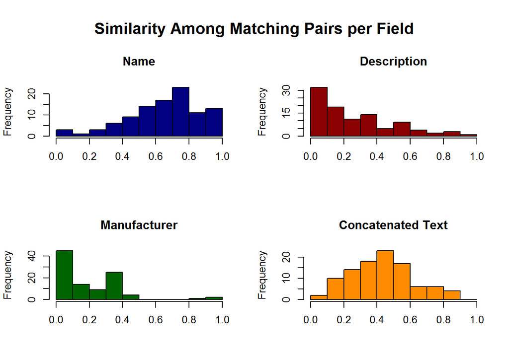

```r
#First look
par(mfrow=c(2,2),oma = c(0, 0, 3, 0))
hist(sample.matches$name,col='navy',xlab='',main='Name',breaks=seq(0,1,.1))
hist(sample.matches$desc,col='darkred',xlab='',main='Description',breaks=seq(0,1,.1))
hist(sample.matches$man,col='darkgreen',xlab='',main='Manufacturer',breaks=seq(0,1,.1))
hist(sample.matches$text,col='darkorange',xlab='',main='Concatenated Text',breaks=seq(0,1,.1))
mtext("Similarity Among Matching Pairs per Field",outer=TRUE,font=2,cex=1.3)
```

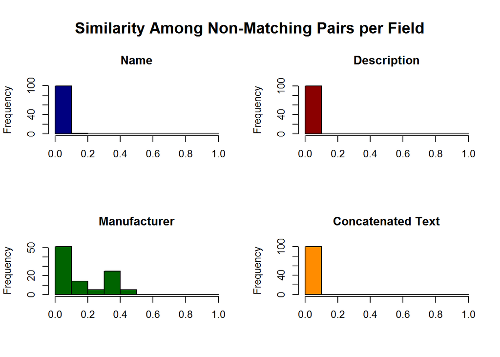

```r
#print(dim(sample.non.matches))
sample.non.matches2=sample.non.matches[sample(1:dim(sample.non.matches)[1],100),]
#sample.non.matches=sample(x=sample.non.matches2,size=100)
par(mfrow=c(2,2),oma = c(0, 0, 3, 0))
hist(sample.non.matches2$name,col='navy',xlab='',main='Name',breaks=seq(0,1,.1))
hist(sample.non.matches2$desc,col='darkred',xlab='',main='Description',breaks=seq(0,1,.1))
hist(sample.non.matches2$man,col='darkgreen',xlab='',main='Manufacturer',breaks=seq(0,1,.1))
hist(sample.non.matches2$text,col='darkorange',xlab='',main='Concatenated Text',breaks=seq(0,1,.1))
mtext("Similarity Among Non-Matching Pairs per Field",outer=TRUE,font=2,cex=1.3)
```

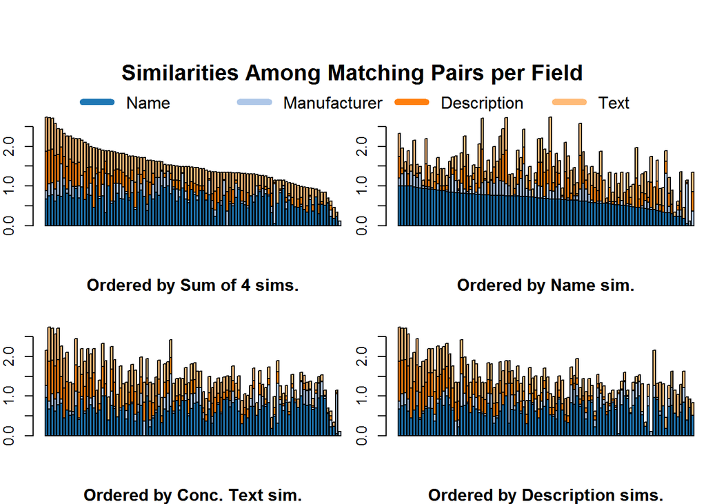

```r
library(dplyr)
pl1=sample.matches[,c(3,5,7,8)] %>% arrange(desc(name+man+desc+text))
pl2=sample.matches[,c(3,5,7,8)] %>% arrange(desc(name))
pl3=sample.matches[,c(3,5,7,8)] %>% arrange(desc(text))
pl4=sample.matches[,c(3,5,7,8)] %>% arrange(desc(desc))

library(ggthemes)
colrs=tableau_color_pal("tableau20")(4)
tx=c('Name','Manufacturer','Description','Text')

par(mfrow=c(2,2),oma=c(0,0,5,0),mar=c(4,2,2,0))
barplot(t(pl1),col=colrs,xlab=('Ordered by Sum of 4 sims.'),font.lab=2,cex.lab=1.2)
barplot(t(pl2),col=colrs,xlab=('Ordered by Name sim.'),font.lab=2,cex.lab=1.2)
barplot(t(pl3),col=colrs,xlab=('Ordered by Conc. Text sim.'),font.lab=2,cex.lab=1.2)
barplot(t(pl4),col=colrs,xlab=('Ordered by Description sims.'),font.lab=2,cex.lab=1.2)
mtext("Similarities Among Matching Pairs per Field",outer=TRUE,font=2,cex=1.3,side=3,adj=.5)
par(new=TRUE)
par(mfrow=c(1,1),oma=c(15.5,0,0,0))
legend('bottom',legend=tx,col=colrs,lty=1,horiz=TRUE,bty='n',lwd=6)
```

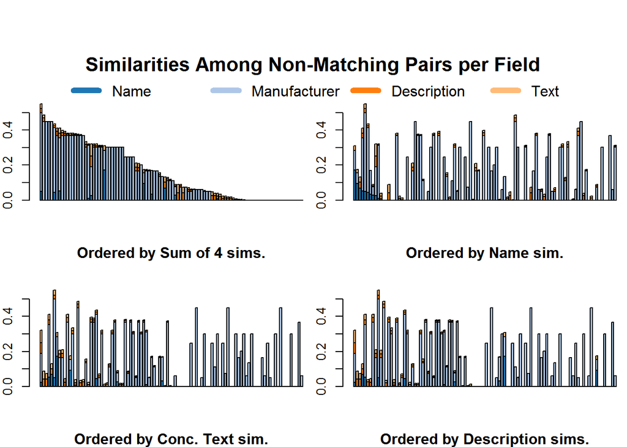

```r
pl1=sample.non.matches2[,c(3,5,7,8)] %>% arrange(desc(name+man+desc+text))
pl2=sample.non.matches2[,c(3,5,7,8)] %>% arrange(desc(name))
pl3=sample.non.matches2[,c(3,5,7,8)] %>% arrange(desc(text))
pl4=sample.non.matches2[,c(3,5,7,8)] %>% arrange(desc(desc))

plot.new()
par(mfrow=c(2,2),oma=c(0,0,5,0),mar=c(4,2,2,0))
barplot(t(pl1),col=colrs,xlab=('Ordered by Sum of 4 sims.'),font.lab=2,cex.lab=1.2)
barplot(t(pl2),col=colrs,xlab=('Ordered by Name sim.'),font.lab=2,cex.lab=1.2)
barplot(t(pl3),col=colrs,xlab=('Ordered by Conc. Text sim.'),font.lab=2,cex.lab=1.2)
barplot(t(pl4),col=colrs,xlab=('Ordered by Description sims.'),font.lab=2,cex.lab=1.2)
mtext("Similarities Among Non-Matching Pairs per Field",outer=TRUE,font=2,cex=1.3,side=3,adj=.5)
par(new=TRUE)
par(mfrow=c(1,1),oma=c(15.5,0,0,0))
legend('bottom',legend=tx,col=colrs,lty=1,horiz=TRUE,bty='n',lwd=6)
```

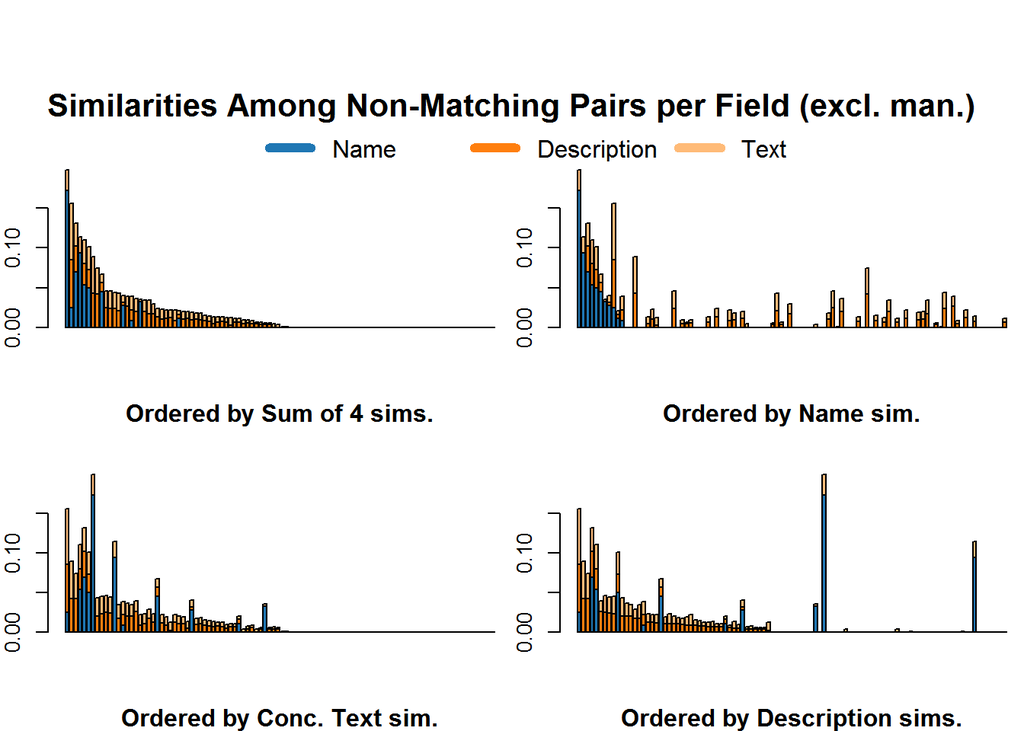

```r
pl1=sample.non.matches2[,c(3,7,8)] %>% arrange(desc(name+desc+text))
pl2=sample.non.matches2[,c(3,7,8)] %>% arrange(desc(name))
pl3=sample.non.matches2[,c(3,7,8)] %>% arrange(desc(text))
pl4=sample.non.matches2[,c(3,7,8)] %>% arrange(desc(desc))
colrs=colrs[c(1,3,4)]
tx=tx[c(1,3,4)]

plot.new()
par(mfrow=c(2,2),oma=c(0,0,5,0),mar=c(4,2,2,0))
barplot(t(pl1),col=colrs,xlab=('Ordered by Sum of 4 sims.'),font.lab=2,cex.lab=1.2)
barplot(t(pl2),col=colrs,xlab=('Ordered by Name sim.'),font.lab=2,cex.lab=1.2)
barplot(t(pl3),col=colrs,xlab=('Ordered by Conc. Text sim.'),font.lab=2,cex.lab=1.2)
barplot(t(pl4),col=colrs,xlab=('Ordered by Description sims.'),font.lab=2,cex.lab=1.2)
mtext("Similarities Among Non-Matching Pairs per Field (excl. man.)",outer=TRUE,font=2,cex=1.3,side=3,adj=.5)
par(new=TRUE)
par(mfrow=c(1,1),oma=c(15.5,0,0,0))
legend('bottom',legend=tx,col=colrs,lty=1,horiz=TRUE,bty='n',lwd=6)
```

Some of these plots are a bit hard to interpret, but they provide valuable insights. From these plots, it can be concluded that:

- Name is the field that better distinguishes matching and non-matching entries.
- Manufacturer (edit distance-based) doesn’t distinguish well between matches and non-matches. The TF-IDFd manufacturer cosine similarity does even worse in this regard and thus it wasn’t even shown in these plots (can be seen from the summary statistics).
- The concatenated text fields’ similarity does a reasonable job at distinguishing non-matches, followed by the description field, but they would miss many matches.

Thus, a possible plan of action would be to try these alternatives:

- Set a cutoff point in name similarity and identify two records as being the same if they are above this threshold. This threshold can be determined by computing the accuracy, precision, recall and F1 that it would have had with this small sample, although this might not necessarily be representative given the huge skew in class proportions.
- Try a combination of these similarities (name, description and concatenated text) to compe up with a score, and identify an appropirate cut-off threshold for this compound similarity, both with a formula (i.e. logistic regression) and with a simple sum.
- Try a decision tree with these 3 similarities.
- Try a Random Forest.

Then pick the one that gives the best results in this small subsample and pick that as the algorithm to follow.

Given that there is a list of matching pairs, I’ll also check the accuracy of these 4 paths on the full list of pairs - this however, wouldn’t be possible to do in a real situation, as there wouldn’t be such list when using real data.

## 8. Building the Models

This dataset has an extremely skewed class balance, as only 0.03% of the possible pairs are matches. Most machine learning classifiers benefit from a smartly plannified resampling that balances the classes in the training set, either by upampling or downsampling, so here I’ll take the approach of upsampling to balance off the matches and non-matches, considering that there are only 100 positve examples (this upsampling is done by bootstrapping with replacement from the minority class). As the machine-learning-based models here will be trained with an artificially-balanced sample, their performance cannot be reliably evaluated with cross-validation and it’s necessary to build a small validation set.

```r
#Constructing the set
sample.matches$label=1
sample.non.matches$label=0
names(sample.non.matches)=names(sample.matches)

library(caret)
trainset=rbind(sample.matches,sample.non.matches)
trainset$label=as.factor(trainset$label)

set.seed(100)
train.sample=sample(1:dim(trainset)[1],round(0.7*dim(trainset)[1],0))
trainset=trainset[train.sample,]
valset=trainset[-train.sample,]
trainset=upSample(x=trainset[,c('name','man','desc','text')],y=trainset[,'label'],yname='label')


valset.simple=rbind(sample.matches,sample.non.matches)

f_1=function(prec,rec){
  return (2*prec*rec/(prec+rec))
}

get.results=function(probs,truth,grid){
  res=data.frame(matrix(nrow=length(grid),ncol=5))
  names(res)=c('thr',"accuracy",'prec','rec','f1')
  counter=0
  for (thr in grid){
    counter=counter+1
    pred=1*(probs>thr)
    res$thr[counter]=thr
    tp=sum((pred==1) * (truth==1))
    tn=sum((pred==0) * (truth==0))
    fp=sum((pred==1) * (truth==0))
    fn=sum((pred==0) * (truth==1))
    res$accuracy[counter]=(tp+tn)/(tp+fp+fn+tn)
    res$prec[counter]=tp/(tp+fp)
    res$rec[counter]=tp/(tp+fn)
    res$f1[counter]=f_1(res$prec[counter],res$rec[counter])
  }
  res$thr=grid
  print(res)

}
```

```r
#Name similarity
grid=c(.01,.02,.05,.1,.15,.25,.4,.5,.6,.7,.9)
get.results(valset.simple$name,valset.simple$label,grid)
```

```
##     thr  accuracy        prec  rec          f1
## 1  0.01 0.9415871 0.005008433 0.98 0.009965933
## 2  0.02 0.9469961 0.005516776 0.98 0.010971787
## 3  0.05 0.9634691 0.007985008 0.98 0.015840944
## 4  0.10 0.9845650 0.018514984 0.97 0.036336393
## 5  0.15 0.9925060 0.037422840 0.97 0.072065379
## 6  0.25 0.9970450 0.086834734 0.93 0.158838599
## 7  0.40 0.9989560 0.206161137 0.87 0.333333333
## 8  0.50 0.9993490 0.285714286 0.78 0.418230563
## 9  0.60 0.9995590 0.365714286 0.64 0.465454545
## 10 0.70 0.9996490 0.423423423 0.47 0.445497630
## 11 0.90 0.9996970 0.481481481 0.13 0.204724409
```

It can be seen that this simple technique did a very good job. A threshold between .4 and .6 name similarity seems to give the best results.

```r
#Simple sum
get.results(valset.simple$name+valset.simple$desc+valset.simple$text,valset.simple$label,c(.5,1,1.5,2,2.5))
```

```
##   thr accuracy       prec  rec         f1
## 1 0.5 0.996946 0.08574007 0.95 0.15728477
## 2 1.0 0.999322 0.27816901 0.79 0.41145833
## 3 1.5 0.999664 0.41428571 0.29 0.34117647
## 4 2.0 0.999715 0.69230769 0.09 0.15929204
## 5 2.5 0.999700 0.50000000 0.01 0.01960784
```

This simple sum seemed to give resonable results so far, with thresholds of .5 and 1.

```r
#The other methods require more data processing
valset$label=as.factor(valset$label)
trainset$label=as.factor(trainset$label)

#Logistic regression
lr=glm(label~name+man+desc+text,data=trainset,family="binomial")
lr.probs=predict(lr,valset,type='response')
get.results(lr.probs,valset$label,grid)
```

```
##     thr  accuracy         prec       rec          f1
## 1  0.01 0.4481164 0.0006976203 1.0000000 0.001394268
## 2  0.02 0.7152968 0.0013014967 0.9629630 0.002599480
## 3  0.05 0.9547803 0.0081402630 0.9629630 0.016144055
## 4  0.10 0.9774971 0.0162297129 0.9629630 0.031921424
## 5  0.15 0.9845890 0.0235294118 0.9629630 0.045936396
## 6  0.25 0.9893408 0.0336787565 0.9629630 0.065081352
## 7  0.40 0.9923373 0.0462633452 0.9629630 0.088285229
## 8  0.50 0.9936644 0.0554371002 0.9629630 0.104838710
## 9  0.60 0.9944777 0.0631067961 0.9629630 0.118451025
## 10 0.70 0.9952483 0.0726256983 0.9629630 0.135064935
## 11 0.90 0.9967751 0.1004016064 0.9259259 0.181159420
```

This simple logistic regression seems to do a reasonable job, achieving more balanced results, but still worse than name similarity.

```r
#Decision tree
library(C50)
tree=C5.0(label~name+man+desc+text,data=trainset)
tree.res=predict(tree,valset,type='class')
get.results.tree=function(pred,truth){
  res=data.frame(matrix(nrow=1,ncol=4))
  names(res)=c("accuracy",'prec','rec','f1')
  counter=0
  tp=sum((pred==1) * (truth==1))
  tn=sum((pred==0) * (truth==0))
  fp=sum((pred==1) * (truth==0))
  fn=sum((pred==0) * (truth==1))
  res$accuracy=(tp+tn)/(tp+fp+fn+tn)
  res$prec=tp/(tp+fp)
  res$rec=tp/(tp+fn)
  res$f1=f_1(res$prec,res$rec)
  print(res)

}
get.results.tree(tree.res,valset$label)
```

```
##    accuracy      prec      rec        f1
## 1 0.9991866 0.3170732 0.962963 0.4770642
```

More complex models such as Random Forests couldn’t be used here due to not having enough memory for a dataset of this size.

Thus, based on this evidence, the most sensible thing would be to keep the name similarity at 0.4, but it’s also interesting to see how would have been the performance of other methods.

## 9. Evaluating the models

This would normally be impossible to do in a real situation, but the models can be evaluated with the list of matching pairs that is available for this dataset.

For this, I’ll use the list of pairs (discarding the ones used to build the model) with their labels and a new up-sampled training set that includes all of the records that were previously used as validation too:

```r
library(caret)
valset.simple$label=as.factor(valset.simple$label)
trainset=upSample(x=valset.simple[,c('name','man','desc','text')],y=valset.simple[,'label'],yname='label')
```

Finally, the models can be evaluated on their results on the full 4M pairs of products:

```r
pred.sum05=1*(all.pairs$sum>=.5)
pred.sum1=1*(all.pairs$sum>=1)
pred.sum15=1*(all.pairs$sum>=1.5)

pred.name4=1*(all.pairs$name>.4)
pred.name6=1*(all.pairs$name>.6)

lr=glm(label~name+man+desc+text,data=trainset,family=binomial(link='probit'))
pred.lr.prob=predict(lr,all.pairs,type='response')
pred.lr7=1*(pred.lr.prob>=.7)
pred.lr99=1*(pred.lr.prob>=.99)

library(C50)
tree=C5.0(label~name+man+desc+text,data=trainset)
tree.res=predict(tree,all.pairs,type='class')

preds=list(pred.sum05,pred.sum1,pred.sum15,pred.name4,pred.name6,pred.lr7,pred.lr99,tree.res)
res=as.data.frame(matrix(nrow=8,ncol=6))
names(res)=c('method','threshold','accuracy','precision','recall','f1')
res$method=c('simple sim. sum','simple sim. sum','simple sim. sum','name sim','name sim','logistic regression','logistic regression','decision tree')
res$threshold=c(.05,1,1.5,.4,.6,.7,.99,.5)
counter=0
for (m in preds){
  counter=counter+1
  tp=sum((m==1) * (all.pairs$label==1))
  tn=sum((m==0) * (all.pairs$label==0))
  fp=sum((m==1) * (all.pairs$label==0))
  fn=sum((m==0) * (all.pairs$label==1))
  res$accuracy[counter]=(tp+tn)/(tp+fp+fn+tn)
  res$precision[counter]=tp/(tp+fp)
  res$recall[counter]=tp/(tp+fn)
  res$f1[counter]=f_1(res$prec[counter],res$rec[counter])
}
print(res)
```

```
##                method threshold  accuracy  precision    recall        f1
## 1     simple sim. sum      0.05 0.9969018 0.08587842 0.9841667 0.1579722
## 2     simple sim. sum      1.00 0.9993235 0.27750646 0.8050000 0.4127323
## 3     simple sim. sum      1.50 0.9996890 0.46483516 0.3525000 0.4009479
## 4            name sim      0.40 0.9989470 0.20456726 0.8883333 0.3325534
## 5            name sim      0.60 0.9995908 0.39002375 0.6841667 0.4968230
## 6 logistic regression      0.70 0.9964646 0.07599665 0.9833333 0.1410893
## 7 logistic regression      0.99 0.9988230 0.19212923 0.9316667 0.3185639
## 8       decision tree      0.50 0.9988614 0.19319606 0.8991667 0.3180545
```

Overall, the name similarity turned out to provide the best mixture, but still at most around 40% precision. Logistic regression did very poorly in terms of precision, no matter how high the threshold.

## 10. Conclusion

Alternatively, it could also be seen as how many records would have to be examined - supposing that records are examined in decreasing order of predicted matching probability - to find a certain percentage of the true matches (known as lift curve).

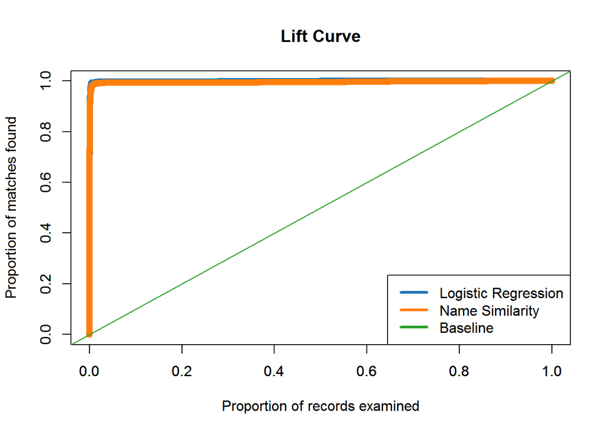

```r
#Constructing the data points
library(dplyr)
end=dim(all.pairs)[1]
cum.matches.name=0
cum.matches.lr=0
cum.time=as.data.frame(matrix(nrow=end,ncol=3))
names(cum.time)=c('picked','match.n','match.lr')
all.pairs$lr=pred.lr.prob
cum.time$picked=1:end
lr=all.pairs %>% arrange(desc(lr))
nm=all.pairs %>% arrange(desc(name))

cum.time$`match.n`=cumsum(1*(nm$label==1))
cum.time$`match.lr`=cumsum(1*(lr$label==1))

#Rescaling the numbers
tot.match=sum(1*(all.pairs$label==1))
tot.picks=dim(all.pairs)[1]
cum.time$`match.n`=(cum.time$`match.n`)/tot.match
cum.time$`match.lr`=cum.time$`match.lr`/tot.match
cum.time$picked=cum.time$picked/tot.picks

#Then plotting them
library(ggthemes)
colors=tableau_color_pal()(3)
plot(cum.time$picked,cum.time$match.lr,xlim=c(0,1),ylim=c(0,1),lty=1,lwd=1,xlab='Proportion of records examined',ylab='Proportion of matches found',main='Lift Curve',col=colors[1])
par(new=TRUE)
plot(cum.time$picked,cum.time$match.n,xlim=c(0,1),ylim=c(0,1),lty=1,lwd=1,col=colors[2],xlab='',ylab='')
abline(0,1,col=colors[3])
legend('bottomright',legend=c('Logistic Regression','Name Similarity','Baseline'),col=colors,lty=1,lwd=3)
```

As can be seen from this plot, the lift is huge, so it’s better to examine it more closely and with numbers:

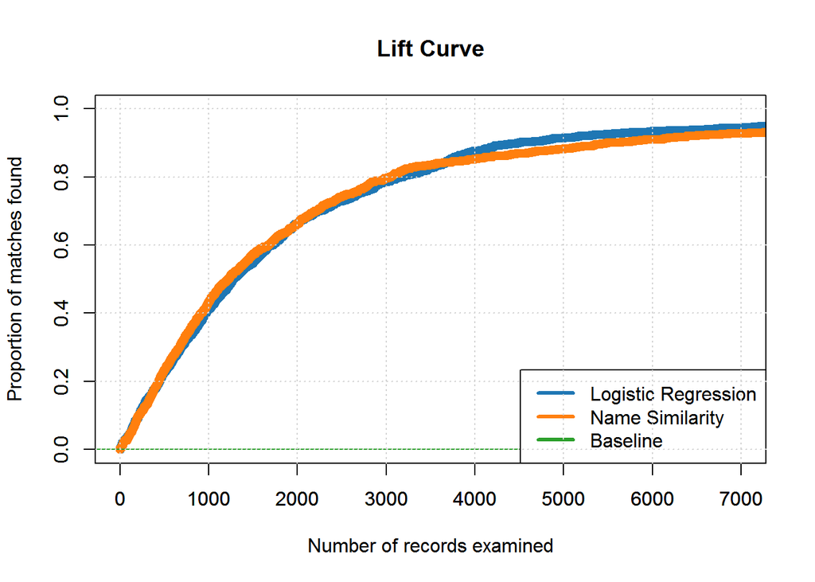

```r
cum.time$picked=1:end
plot(cum.time$picked,cum.time$match.lr,xlim=c(0,7000),ylim=c(0,1),lty=1,lwd=1,xlab='Number of records examined',ylab='Proportion of matches found',main='Lift Curve',col=colors[1])
par(new=TRUE)
plot(cum.time$picked,cum.time$match.n,xlim=c(0,7000),ylim=c(0,1),lty=1,lwd=1,col=colors[2],xlab='',ylab='')
abline(0,1/tot.picks,col=colors[3])
legend('bottomright',legend=c('Logistic Regression','Name Similarity','Baseline'),col=colors,lty=1,lwd=3)
grid()
```

As can be seen, with the first 3,000 highest predictions, around 80% of the remaining 1,200 matching pairs are identified with either method, with 32% of them being matches (compared to 0.03% matches with random choices), which, although far from perfect, is a huge improvement.